# Notes on Statistics

# Part III: High-Throughput Data

```r
#source("http://bioconductor.org/biocLite.R")
suppressMessages(library(Biobase))
#biocLite(c("genefilter", "hgfocus.db"))
suppressMessages(library(genefilter))
#library(hgfocus.db)

library(GSE5859Subset)
data(GSE5859Subset)

dim(geneExpression)
```

```
## [1] 8793   24
```

```r
cat(nrow(geneExpression), "RNA gene expressions for", ncol(geneExpression), "samples")
```

```
## 8793 RNA gene expressions for 24 samples
```

```r
dim(sampleInfo)
```

```
## [1] 24  4
```

```r
dim(geneAnnotation)
```

```
## [1] 8793    4
```

```r
head(geneExpression, 1)
```

```
##           GSM136508.CEL.gz GSM136530.CEL.gz GSM136517.CEL.gz
## 1007_s_at         6.543954          6.40147         6.298943
##           GSM136576.CEL.gz GSM136566.CEL.gz GSM136574.CEL.gz
## 1007_s_at         6.837899         6.470689          6.45022
##           GSM136575.CEL.gz GSM136569.CEL.gz GSM136568.CEL.gz
## 1007_s_at         6.052854         6.387026         6.640583
##           GSM136559.CEL.gz GSM136565.CEL.gz GSM136573.CEL.gz
## 1007_s_at         6.948474         6.778464         6.595414
##           GSM136523.CEL.gz GSM136509.CEL.gz GSM136727.CEL.gz
## 1007_s_at         6.255549         6.379983         6.133068
##           GSM136510.CEL.gz GSM136515.CEL.gz GSM136522.CEL.gz
## 1007_s_at         6.502051         6.331567         6.354293
##           GSM136507.CEL.gz GSM136524.CEL.gz GSM136514.CEL.gz
## 1007_s_at         6.517539         6.156754         6.037871
##           GSM136563.CEL.gz GSM136564.CEL.gz GSM136572.CEL.gz
## 1007_s_at         6.639091         6.393338         6.469794
```

```r
head(sampleInfo) # filename, column key
```

```
##     ethnicity       date         filename group
## 107       ASN 2005-06-23 GSM136508.CEL.gz     1
## 122       ASN 2005-06-27 GSM136530.CEL.gz     1
## 113       ASN 2005-06-27 GSM136517.CEL.gz     1
## 163       ASN 2005-10-28 GSM136576.CEL.gz     1
## 153       ASN 2005-10-07 GSM136566.CEL.gz     1
## 161       ASN 2005-10-07 GSM136574.CEL.gz     1
```

```r
head(geneAnnotation) # PROBEID, row key
```

```
##      PROBEID  CHR     CHRLOC SYMBOL
## 1  1007_s_at chr6   30852327   DDR1
## 30   1053_at chr7  -73645832   RFC2
## 31    117_at chr1  161494036  HSPA6
## 32    121_at chr2 -113973574   PAX8
## 33 1255_g_at chr6   42123144 GUCA1A
## 34   1294_at chr3  -49842638   UBA7
```

## Mean Test

Expressions (rows) t-test

```r
# first expression
t.test(geneExpression[1, sampleInfo$group==1], geneExpression[1, sampleInfo$group==0], var.equal=TRUE)$p.value
```

```
## [1] 0.04553344
```

```r
# all expressions
pvals <- apply(geneExpression, 1, function(x) t.test(x[sampleInfo$group==1], x[sampleInfo$group==0], var.equal=TRUE)$p.value)
head(pvals)
```

```
##  1007_s_at    1053_at     117_at     121_at  1255_g_at    1294_at
## 0.04553344 0.03370683 0.13604026 0.59413846 0.96849102 0.08489586
```

```r
#genefilter, faster
results <- rowttests(geneExpression, factor(sampleInfo$group))
max(abs(pvals - results$p)) # 0
```

```
## [1] 6.528111e-14
```

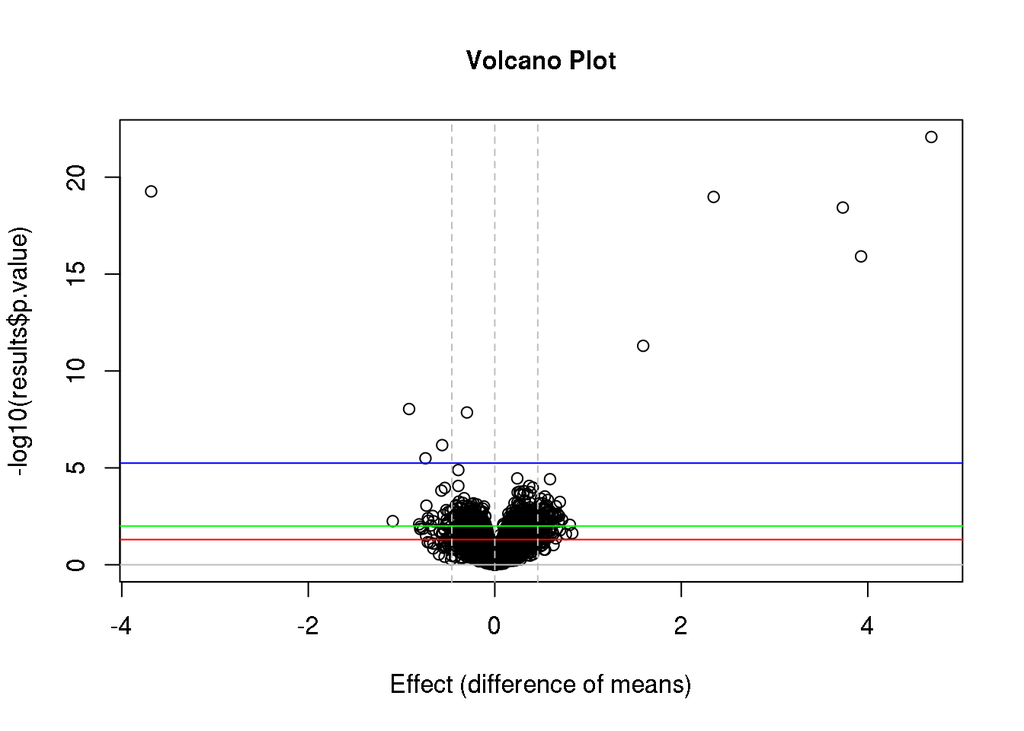

```r
plot(results$dm, -log10(results$p.value),
     xlab="Effect (difference of means)", main="Volcano Plot")
abline(h=-log10(c(0.01, 0.05, 1, 0.05 / nrow(geneExpression))), col=c("green", "red", "gray", "blue"))
abline(v=c(-2.5*sd(results$dm), 0, 2.5*sd(results$dm)), col="gray", lty=2)
```

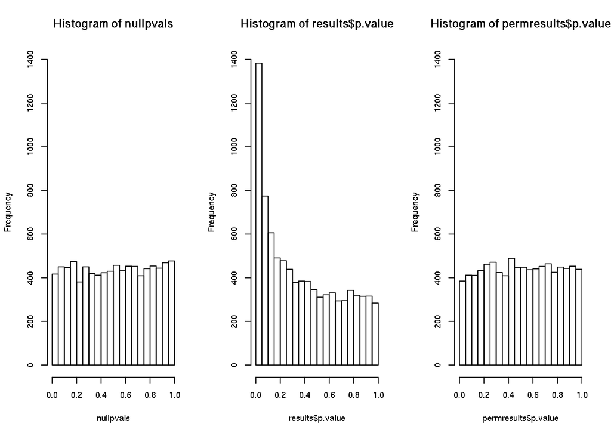

```r
m <- nrow(geneExpression)
n <- ncol(geneExpression)
library(genefilter)
randomData <- matrix(rnorm(n * m), m, n)
nullpvals <- rowttests(randomData, factor(sampleInfo$group))$p.value

permg <- sample(factor(sampleInfo$group))
permresults <- rowttests(geneExpression,permg)

op <- par(mfrow = c(1, 3))
hist(nullpvals, ylim=c(0, 1400)) # null
hist(results$p.value, ylim=c(0, 1400)) # correlated samples
hist(permresults$p.value, ylim=c(0, 1400)) # must be uniform for independed samples
```

```r
par(op)
```

1. Familywise error rate (FWER) (p-values correction, assuming independence):

```r
sidak <- function(a, m) { 1 - (1 - a ) ^ (1 / m) }
bonferroni <- function(a, m) { a / m }

alpha <- 0.05
# no correction
p <- results$p.value <= alpha
c(mean(p), sum(p))
```

```
## [1]    0.1572842 1383.0000000
```

```r
# FWER <= alpha, probability of having at least one false positive
p <- results$p.value <= sidak(alpha, nrow(geneExpression))
c(mean(p), sum(p))
```

```
## [1]  0.001137268 10.000000000
```

```r
p <- results$p.value <= bonferroni(alpha, nrow(geneExpression))
c(mean(p), sum(p))
```

```
## [1]  0.001137268 10.000000000
```

```r
# p.adjust
p <- p.adjust(results$p.value, method="bonferroni") <= alpha
c(mean(p), sum(p))
```

```
## [1]  0.001137268 10.000000000
```

2. False discovery rate (FDR) expected rate of rejecting null hypothesis (FWER = FDR <= q). q-value of a feature is the FDR of the biggest list that includes that gene

```r
q <- p.adjust(results$p.value, method="fdr")
sum(q <= alpha)
```

```
## [1] 13
```

```r
#biocLite("qvalue")
library(qvalue)
q <- qvalue(results$p.value)
length(q$qvalues[q$qvalues <= alpha])
```

```
## [1] 17
```

```r
#or
q <- qvalue(results$p.value, fdr.level=alpha)
sum(q$significant[q$significant == TRUE])
```

```
## [1] 17
```

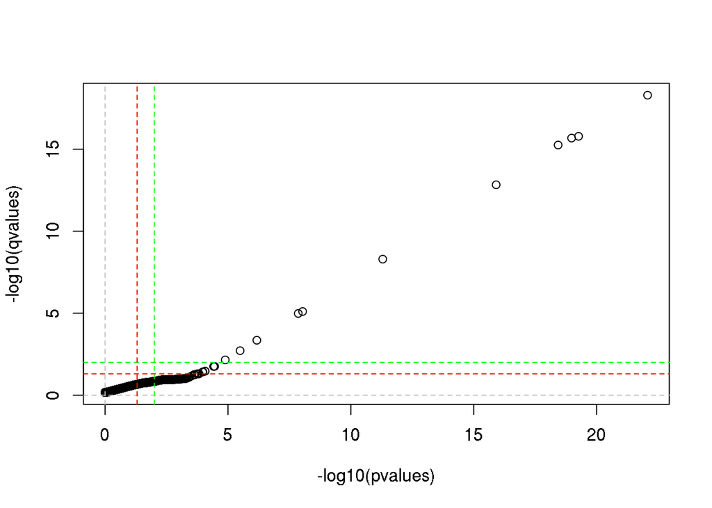

```r
plot(-log10(results$p.value), -log10(qvalue(results$p.value)$qvalues), ylab="-log10(qvalues)", xlab="-log10(pvalues)")
abline(v=-log10(c(0.01, 0.05, 1)), h=-log10(c(0.01, 0.05, 1)), col=c("green", "red", "gray"), lty=2)
```

Sample (column) quantiles

```r
qs <- t(apply(geneExpression, 2, quantile, prob=c(0.05,0.25,0.5,0.75,0.95)))
dim(qs)
```

```
## [1] 24  5
```

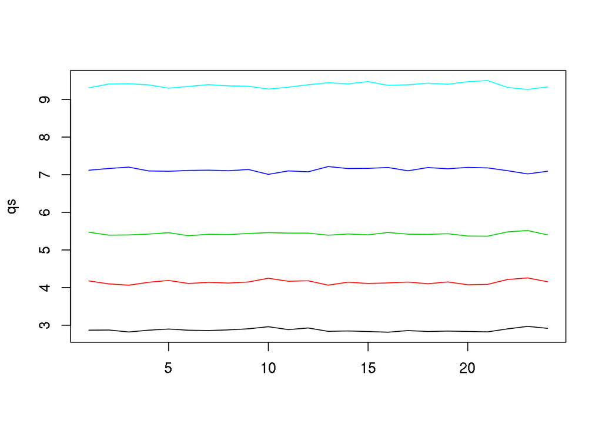

```r
matplot(qs, type="l", lty=1)
```

Hierachical SD correction (shrink $\sigma$ towards common one)

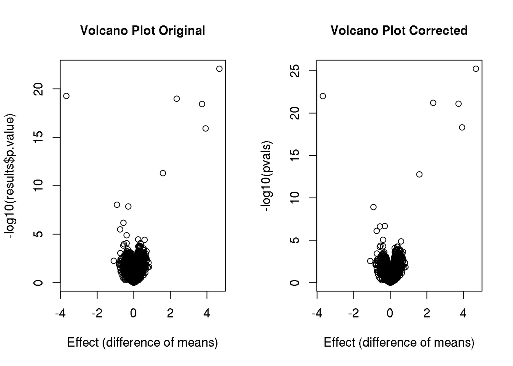

```r
g <- factor(sampleInfo$group)
suppressMessages(library(limma))
fit <- lmFit(geneExpression, design=model.matrix(~ g))
fit <- eBayes(fit)
#second coefficient relates to diffences between groups
pvals <- fit$p.value[,2]
op <- par(mfrow = c(1, 2))
plot(results$dm, -log10(results$p.value),
     xlab="Effect (difference of means)", main="Volcano Plot Original")
plot(results$dm, -log10(pvals),
     xlab="Effect (difference of means)", main="Volcano Plot Corrected")
```

```r
par(op)
```

## Singular Value Decomposition

$\mathbf{Y = UDV^\top}$

Where:

- $\mathbf{Y}$ is an $m\times n$
- $\mathbf{U}$ is an $m\times n$ orthogonal matrix ($UU^T=I$)
- $\mathbf{V}$ is an $n\times n$ orthogonal matrix ($VV^T=I$)
- $\mathbf{D}$ is an $n\times n$ diagonal matrix

Variance of columns of $UD$, $VD$ is decreasing.

Or $\mathbf{Y = UZ}$ where $\mathbf{Z = DV^\top}$

```r
(Y <- matrix(1:15,5,3))
```

```
##      [,1] [,2] [,3]
## [1,]    1    6   11
## [2,]    2    7   12
## [3,]    3    8   13
## [4,]    4    9   14
## [5,]    5   10   15
```

```r
cor(Y) # high correlation in example
```

```
##      [,1] [,2] [,3]
## [1,]    1    1    1
## [2,]    1    1    1
## [3,]    1    1    1
```

```r
rowMeans(Y)
```

```
## [1]  6  7  8  9 10
```

```r
SVD <- svd(Y)
SVD$u
```

```
##            [,1]        [,2]        [,3]
## [1,] -0.3545571  0.68868664  0.57004417
## [2,] -0.3986964  0.37555453 -0.74547800
## [3,] -0.4428357  0.06242242 -0.17015793
## [4,] -0.4869750 -0.25070970  0.29657318
## [5,] -0.5311143 -0.56384181  0.04901858
```

```r
cor(SVD$u[,1], rowMeans(Y))
```

```
## [1] -1
```

```r
diag(SVD$d)
```

```
##          [,1]     [,2]         [,3]
## [1,] 35.12722 0.000000 0.000000e+00
## [2,]  0.00000 2.465397 0.000000e+00
## [3,]  0.00000 0.000000 1.269091e-15
```

```r
SVD$v
```

```
##            [,1]       [,2]       [,3]
## [1,] -0.2016649 -0.8903171  0.4082483
## [2,] -0.5168305 -0.2573316 -0.8164966
## [3,] -0.8319961  0.3756539  0.4082483
```

```r
(Y1 <- SVD$u %*% diag(SVD$d) %*% t(SVD$v))
```

```
##      [,1] [,2] [,3]
## [1,]    1    6   11
## [2,]    2    7   12
## [3,]    3    8   13
## [4,]    4    9   14
## [5,]    5   10   15
```

```r
max(abs(Y - Y1)) #0
```

```
## [1] 7.105427e-15
```

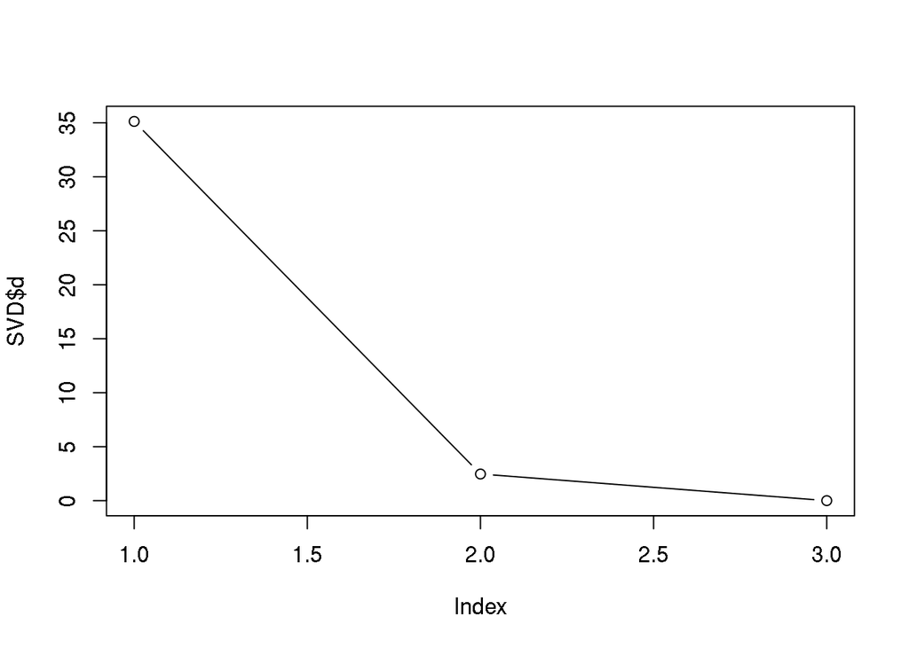

```r
plot(SVD$d, type="b")
```

```r
from.svd <- function(SVD, k) {
  SVD$u[,1:k] %*% diag(SVD$d[1:k], k, k) %*% t(SVD$v[,1:k])
}
# optimized: Y = U %*% Z, Z = D %*% t(V)
svd.z <- function(SVD, k) {
  SVD$d[1:k] * t(SVD$v[,1:k]) # Y = U %*% Z, Z = D %*% t(V)
}
from.svd.optimized <- function(SVD, k) {
  Z <- svd.z(SVD, k)
  tcrossprod(SVD$u[,1:k], t(Z))
}

(Y2<- from.svd(SVD, 2))
```

```
##      [,1] [,2] [,3]
## [1,]    1    6   11
## [2,]    2    7   12
## [3,]    3    8   13
## [4,]    4    9   14
## [5,]    5   10   15
```

```r
(Y2<- from.svd.optimized(SVD, 2))
```

```
##      [,1] [,2] [,3]
## [1,]    1    6   11
## [2,]    2    7   12
## [3,]    3    8   13
## [4,]    4    9   14
## [5,]    5   10   15
```

```r
max(abs(Y - Y2)) #0
```

```
## [1] 7.105427e-15
```

```r
(Y2<- from.svd(SVD, 1))
```

```
##          [,1]     [,2]     [,3]
## [1,] 2.511657 6.436920 10.36218
## [2,] 2.824337 7.238261 11.65219
## [3,] 3.137016 8.039602 12.94219
## [4,] 3.449696 8.840944 14.23219
## [5,] 3.762376 9.642285 15.52219
```

```r
max(abs(Y - Y2)) #0
```

```
## [1] 1.511657
```

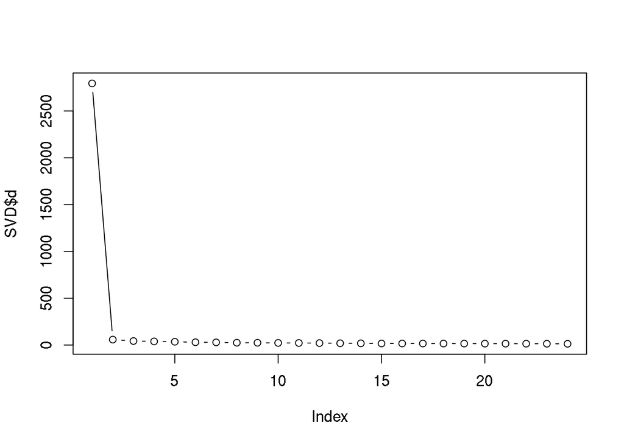

```r
SVD <- svd(geneExpression)
plot(SVD$d, type="b")
```

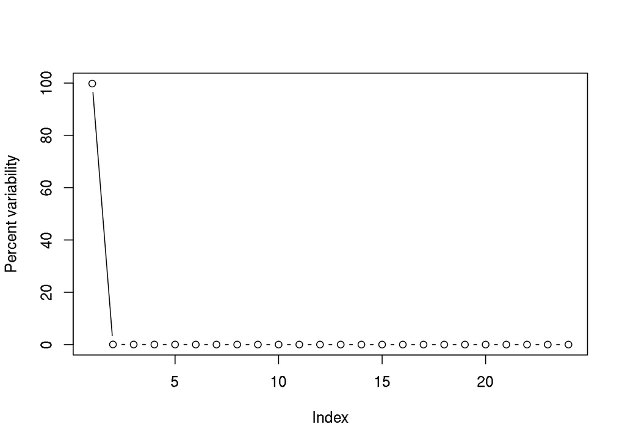

```r
plot(SVD$d^2/sum(SVD$d^2) * 100, type="b", ylab="Percent variability")
```

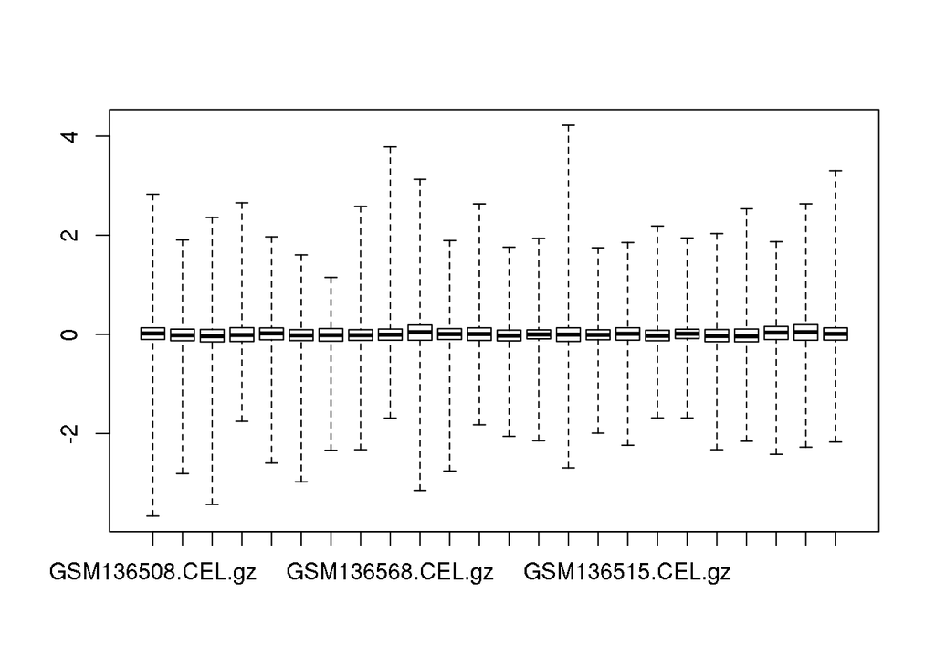

```r
boxplot(geneExpression - from.svd(SVD, 2), range=0)
```

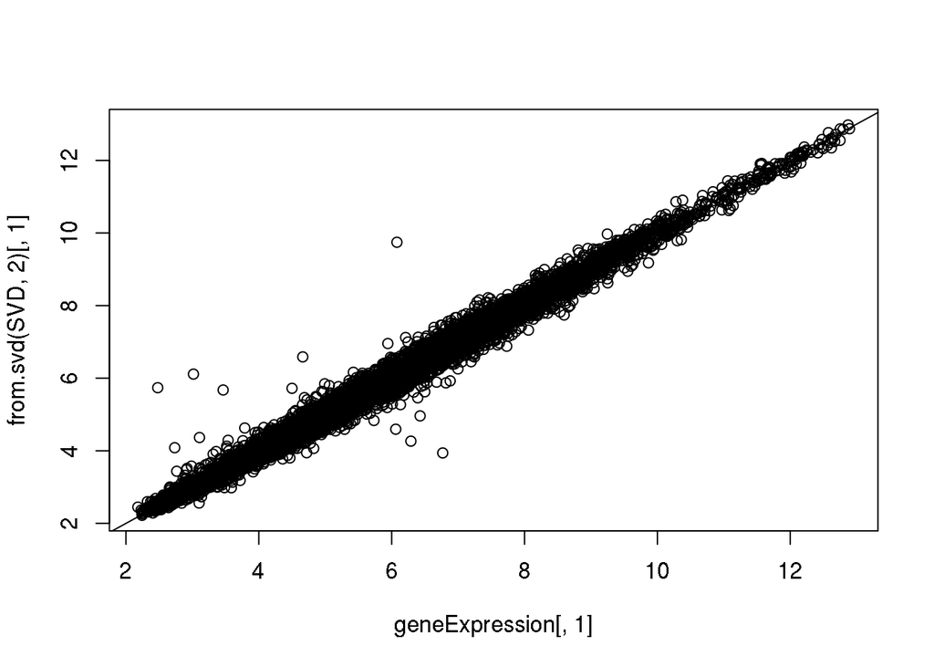

```r
plot(geneExpression[,1], from.svd(SVD, 2)[,1])
abline(0,1)
```

## Sample Distance

Sample i and j Euclidean dinstance: $d(i,j) = \sqrt{ (Y_i - Y_j)^T (Y_i - Y_j) }$

```r
d <- dist(t(geneExpression)) # t() to get columns (sample) distance
dm <- as.matrix(d)
dim(dm)
```

```
## [1] 24 24
```

```r
dm[1, 1]
```

```
## [1] 0
```

```r
dm[1, 2]
```

```
## [1] 30.15294
```

```r
# sqrt(sum((x - y)^2))
sqrt(crossprod(geneExpression[, 1] - geneExpression[, 2])) # same
```

```
##          [,1]
## [1,] 30.15294
```

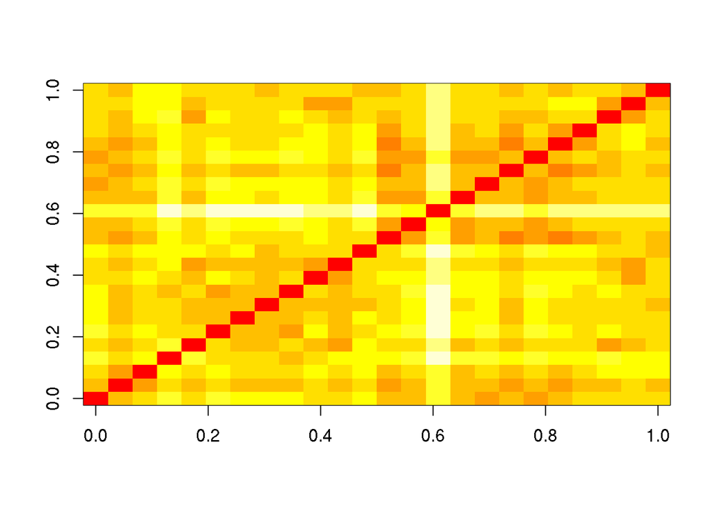

```r
image(dm)
```

SVD

```r
dim(geneExpression)
```

```
## [1] 8793   24
```

```r
SVD <- svd(geneExpression)
Z <- SVD$d * t(SVD$v)
mean(abs(Z - sweep(t(SVD$v), 1, SVD$d, FUN="*"))) #0
```

```
## [1] 0
```

```r
dim(Z)
```

```
## [1] 24 24
```

```r
Y <- from.svd(SVD, 24)
dim(Y)
```

```
## [1] 8793   24
```

```r
Y1 <- from.svd(SVD, 20) # approximation
dim(Y1)
```

```
## [1] 8793   24
```

```r
sqrt(crossprod(geneExpression[,1]-geneExpression[,2]))
```

```
##          [,1]
## [1,] 30.15294
```

```r
sqrt(crossprod(Z[,1]-Z[,2]))
```

```
##          [,1]
## [1,] 30.15294
```

```r
sqrt(crossprod(Y[,1]-Y[,2]))
```

```
##          [,1]
## [1,] 30.15294
```

```r
(approx <- sqrt(crossprod(Y1[,1] - Y1[,2])))
```

```
##          [,1]
## [1,] 28.09941
```

```r
(dm[1, 2] - approx) / dm[1, 2] * 100 # difference in %
```

```
##          [,1]
## [1,] 6.810391
```

Multi-dimensional scaling (MDS) using first two columns of Z:

$d(Y[i], Y[j]) \approx d(Z[,i], Z[,j])$

points(x=Z[1,], y=Z[2,])

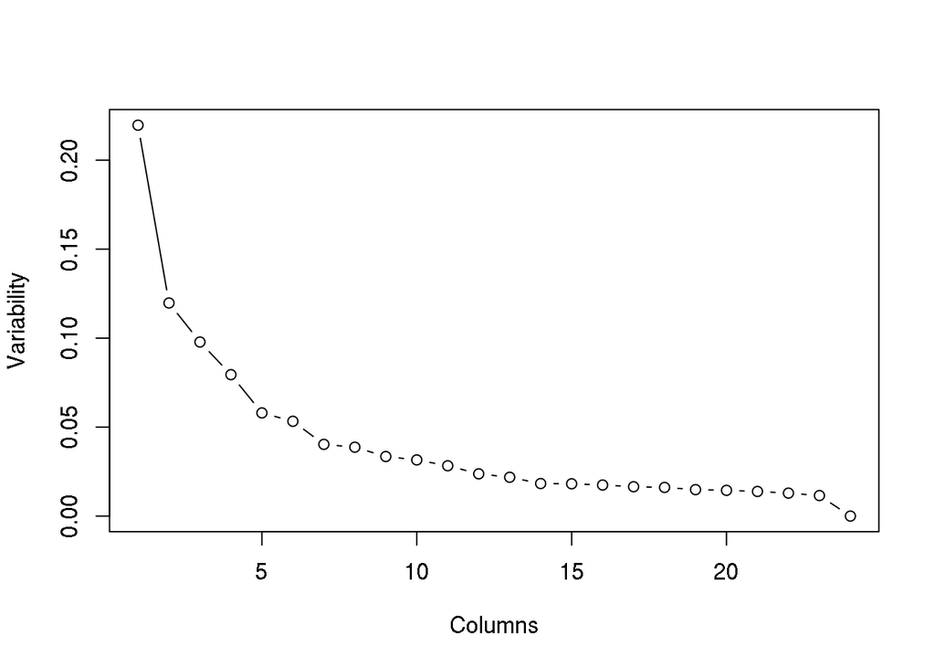

```r
SVD <- svd(geneExpression - rowMeans(geneExpression)) # scale
plot(SVD$d^2/sum(SVD$d^2), type="b", ylab="Variability", xlab="Columns")
```

```r
Z <- svd.z(SVD, 2)
dim(Z) # 24 samples of 2D points
```

```
## [1]  2 24
```

```r
head(t(Z))
```

```
##             [,1]       [,2]
## [1,] -13.6121155 -0.7305893
## [2,]  -1.9999525 -6.0204521
## [3,]  -4.8650113 -8.4022714
## [4,]  17.8965913 -3.1738972
## [5,]   0.2256007  7.7301905
## [6,]  20.6429118 -3.9169241
```

```r
head(sweep(SVD$v[,1:2], 2, SVD$d[1:2], "*"))
```

```
##             [,1]       [,2]
## [1,] -13.6121155 -0.7305893
## [2,]  -1.9999525 -6.0204521
## [3,]  -4.8650113 -8.4022714
## [4,]  17.8965913 -3.1738972
## [5,]   0.2256007  7.7301905
## [6,]  20.6429118 -3.9169241
```

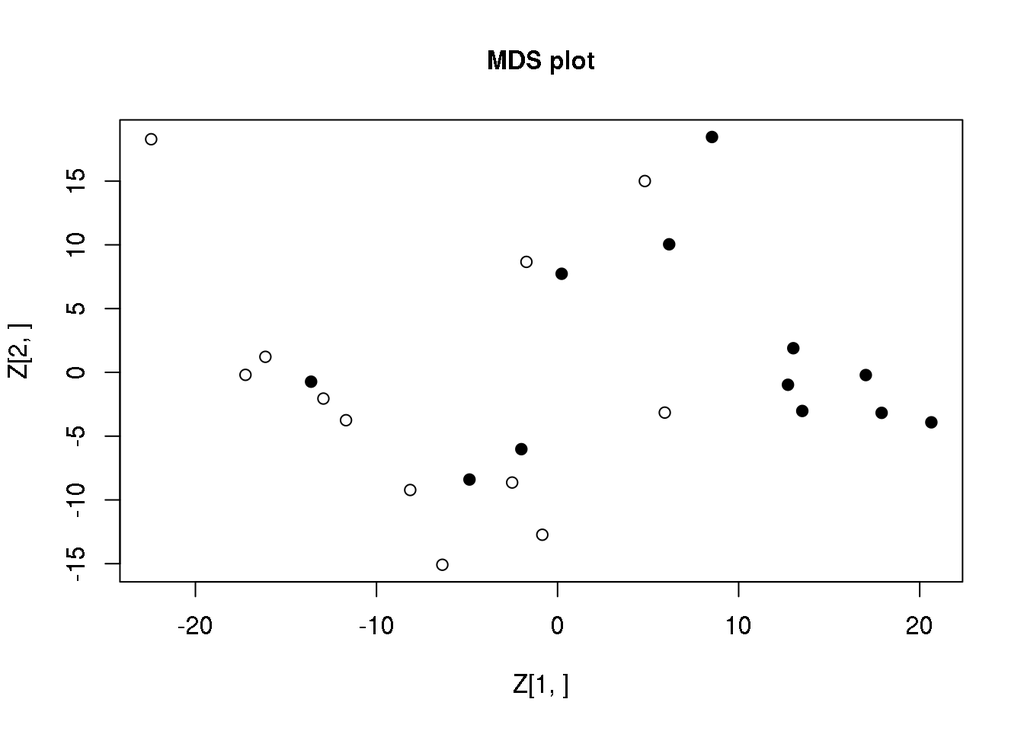

```r
# plot of approximated sample distance
plot(Z[1,], Z[2,], bg=as.numeric(sampleInfo$group), pch=21, main="MDS plot")
```

d from Z

```r
d.from.Z <- function (Z) {
  n <- ncol(Z)
  d <- matrix(0, n, n)
  for(i in 1:n)
    for(j in 1:n)
      if(i != j)
        d[i,j] <- d[j,i] <- sqrt(crossprod(Z[,i] - Z[,j]))
  d
}
SVD <- svd(geneExpression)
Z <- svd.z(SVD, 24)
dz <- d.from.Z(Z)
dz[1, 2]
```

```
## [1] 30.15294
```

```r
dz[2, 1]
```

```
## [1] 30.15294
```

```r
Z2 <- svd.z(SVD, 2)
dz2 <- d.from.Z(Z2)
dz2[1, 2]
```

```
## [1] 11.64905
```

```r
dz2[2, 1]
```

```
## [1] 11.64905
```

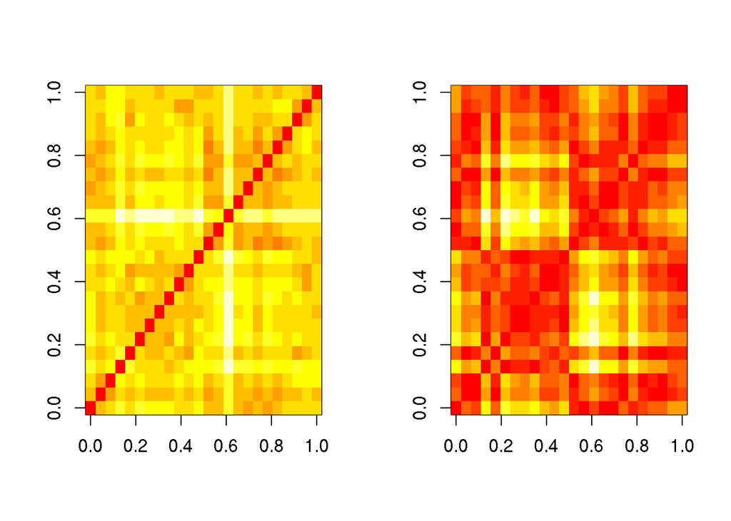

```r
op <- par(mfrow = c(1, 2))
image(dz)
image(dz2)
```

```r
par(op)
```

R

```r
d <- dist(t(geneExpression))
mds <- cmdscale(d,k=2)
dim(mds)
```

```
## [1] 24  2
```

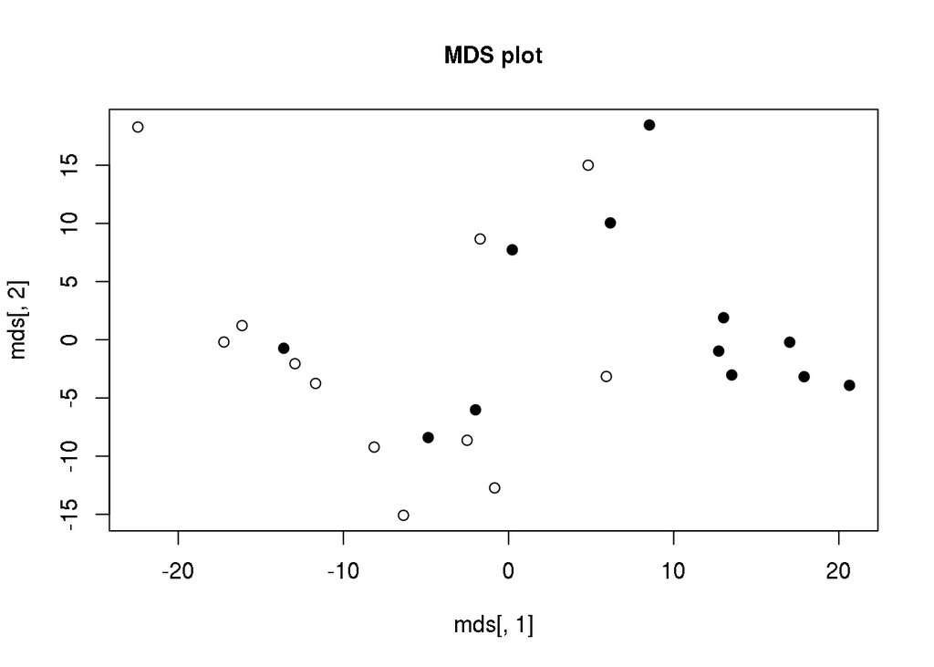

```r
plot(mds[,1], mds[,2], bg=as.numeric(sampleInfo$group), pch=21, main="MDS plot")
```

## Clustering

```r
#devtools::install_github("genomicsclass/tissuesGeneExpression")
library(tissuesGeneExpression)
data(tissuesGeneExpression)
dim(e)
```

```
## [1] 22215   189
```

```r
length(tissue)
```

```
## [1] 189
```

```r
d <- dist(t(e))
SVD <- svd(e)
Z2 <- svd.z(SVD, 2)
dz2 <- d.from.Z(Z2)
dim(dz2)
```

```
## [1] 189 189
```

1. Hierarchical

```r
(hc <- hclust(d))
```

```
##
## Call:
## hclust(d = d)
##
## Cluster method   : complete
## Distance         : euclidean
## Number of objects: 189
```

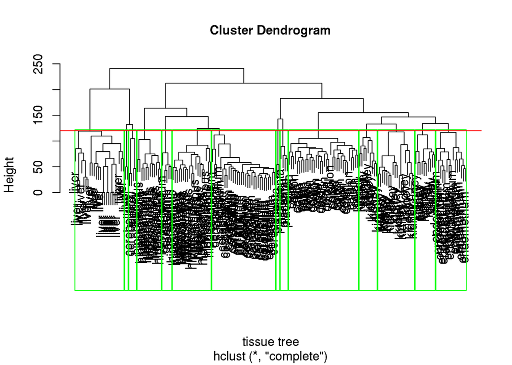

```r
plot(hc, labels=tissue, xlab="tissue tree")
rect.hclust(hc, k = 14, border = "green")
abline(h=120, col="red")
```

```r
hclusters <- cutree(hc, k=14)
length(hclusters) # sample in cluster
```

```
## [1] 189
```

```r
table(known.group=tissue, found.cluster=hclusters)
```

```
##              found.cluster
## known.group    1  2  3  4  5  6  7  8  9 10 11 12 13 14
##   cerebellum   0  0  0  0 31  0  0  0  2  0  0  5  0  0
##   colon        0  0  0  0  0  0 34  0  0  0  0  0  0  0
##   endometrium  0  0  0  0  0  0  0  0  0  0 15  0  0  0
##   hippocampus  0  0 12 19  0  0  0  0  0  0  0  0  0  0
##   kidney       9 18  0  0  0 10  0  0  2  0  0  0  0  0
##   liver        0  0  0  0  0  0  0 24  0  2  0  0  0  0
##   placenta     0  0  0  0  0  0  0  0  0  0  0  0  2  4
```

```r
hclusters <- cutree(hc, h=120)
table(known.group=tissue, found.cluster=hclusters)
```

```
##              found.cluster
## known.group    1  2  3  4  5  6  7  8  9 10 11 12 13 14
##   cerebellum   0  0  0  0 31  0  0  0  2  0  0  5  0  0
##   colon        0  0  0  0  0  0 34  0  0  0  0  0  0  0
##   endometrium  0  0  0  0  0  0  0  0  0  0 15  0  0  0
##   hippocampus  0  0 12 19  0  0  0  0  0  0  0  0  0  0
##   kidney       9 18  0  0  0 10  0  0  2  0  0  0  0  0
##   liver        0  0  0  0  0  0  0 24  0  2  0  0  0  0
##   placenta     0  0  0  0  0  0  0  0  0  0  0  0  2  4
```

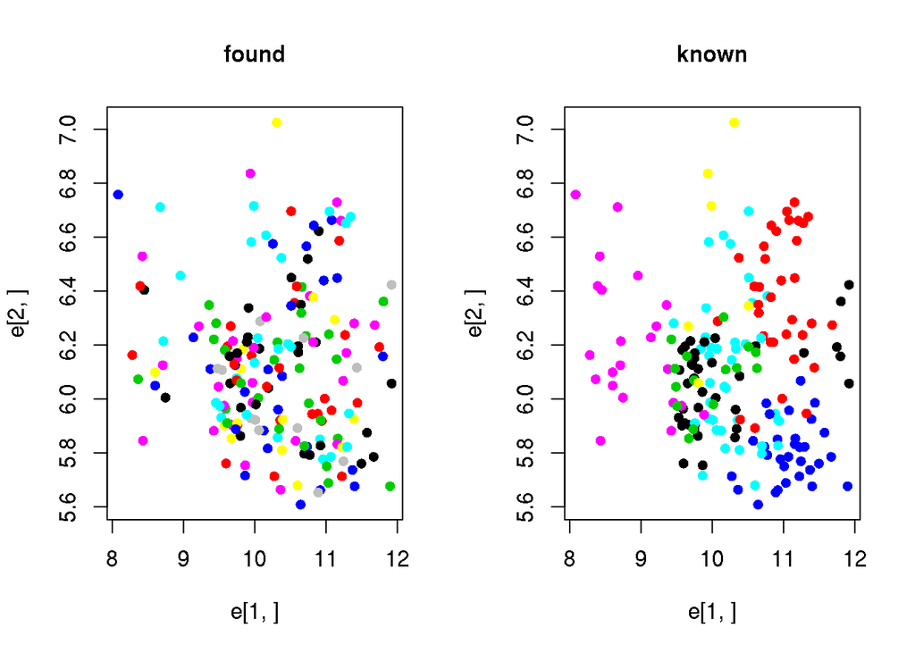

```r
op <- par(mfrow = c(1, 2))
plot(e[1,], e[2,], col=1:length(unique(hclusters)), pch=16, main="found")
plot(e[1,], e[2,], col=as.numeric(factor(tissue)), pch=16, main="known")
```

```r
par(op)
```

Approx. Z2

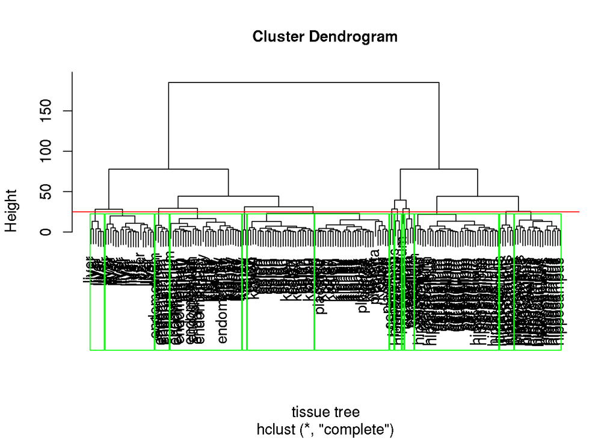

```r
hc <- hclust(as.dist(dz2))
plot(hc, labels=tissue, xlab="tissue tree")
rect.hclust(hc, k = 14, border = "green")
abline(h=25, col="red")
```

```r
hclusters <- cutree(hc, k=14)
table(known.group=tissue, found.cluster=hclusters)
```

```
##              found.cluster
## known.group    1  2  3  4  5  6  7  8  9 10 11 12 13 14
##   cerebellum   0  0  1  2  0 28  0  0  0  2  0  0  1  4
##   colon        0 11  0  0  0  0 23  0  0  0  0  0  0  0
##   endometrium  9  0  0  0  0  0  0  0  0  0  0  6  0  0
##   hippocampus  0  0  5 17  3  6  0  0  0  0  0  0  0  0
##   kidney      18 15  0  0  0  0  4  0  0  0  2  0  0  0
##   liver        0  0  0  0  0  0  0  6 20  0  0  0  0  0
##   placenta     2  4  0  0  0  0  0  0  0  0  0  0  0  0
```

2. k-means

```r
km <- kmeans(t(e[1:2,]), centers=7)
names(km)
```

```
## [1] "cluster"      "centers"      "totss"        "withinss"
## [5] "tot.withinss" "betweenss"    "size"         "iter"
## [9] "ifault"
```

```r
length(km$cluster)
```

```
## [1] 189
```

```r
table(known.group=tissue, found.cluster=km$cluster)
```

```
##              found.cluster
## known.group    1  2  3  4  5  6  7
##   cerebellum   1 24  0  6  7  0  0
##   colon       24  0  2  5  2  0  1
##   endometrium  2  8  0  0  5  0  0
##   hippocampus  0  0 19 10  2  0  0
##   kidney       4  6  7  0 18  0  4
##   liver        0  8  0  0  0 18  0
##   placenta     1  2  0  0  0  0  3
```

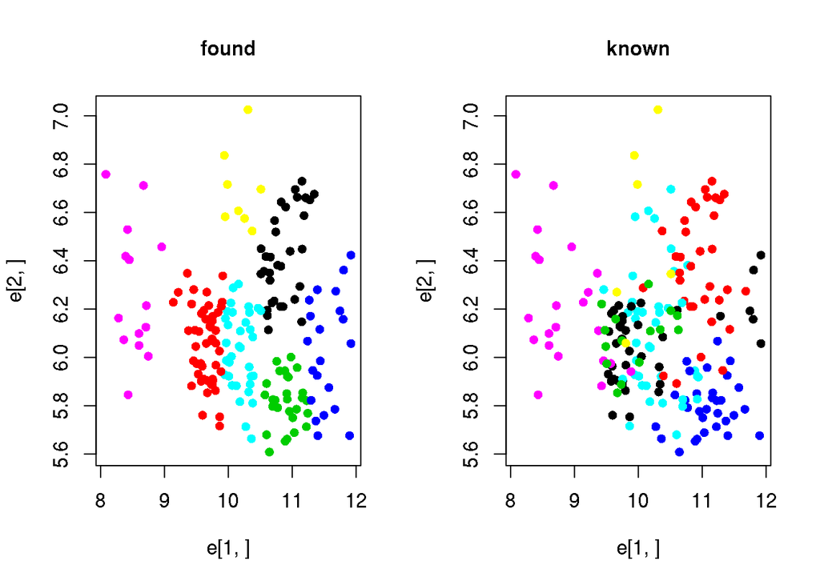

```r
op <- par(mfrow = c(1, 2))
plot(e[1,], e[2,], col=km$cluster, pch=16, main="found")
plot(e[1,], e[2,], col=as.numeric(factor(tissue)), pch=16, main="known")
```

```r
par(op)

#using mds
km <- kmeans(t(e), centers=7)
table(known.group=tissue, found.cluster=km$cluster)
```

```
##              found.cluster
## known.group    1  2  3  4  5  6  7
##   cerebellum   0  6  0  0 30  2  0
##   colon        0  0 34  0  0  0  0
##   endometrium  0  0  0 15  0  0  0
##   hippocampus  0 13  0  0  0  0 18
##   kidney       0  0 37  0  0  2  0
##   liver       24  0  0  0  0  2  0
##   placenta     0  0  6  0  0  0  0
```

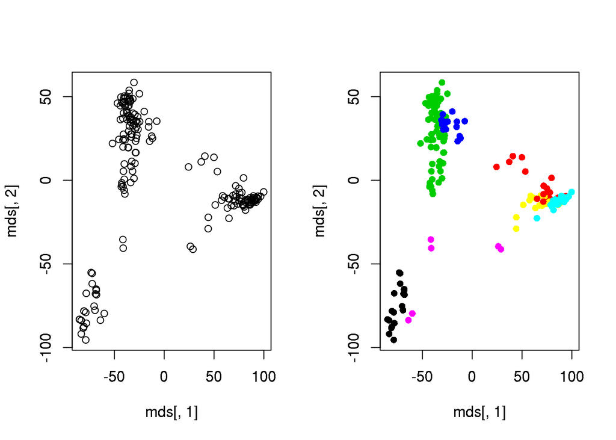

```r
mds <- cmdscale(d)
op <- par(mfrow = c(1, 2))
plot(mds[,1], mds[,2])
plot(mds[,1], mds[,2], col=km$cluster, pch=16)
```

```r
par(op)
```

Approx. Y2

```r
Y2 <- from.svd(SVD, 2)
km <- kmeans(t(Y2[1:2,]), centers=7)
table(known.group=tissue, found.cluster=km$cluster)
```

```
##              found.cluster
## known.group    1  2  3  4  5  6  7
##   cerebellum   0  0  0  0 34  0  4
##   colon        0  0 15  0  0 19  0
##   endometrium  8  3  0  0  0  4  0
##   hippocampus  0  0  0  0 25  0  6
##   kidney       6 14  3  2  0 14  0
##   liver        0  0  0 26  0  0  0
##   placenta     0  1  2  0  0  3  0
```

3. Heatmap

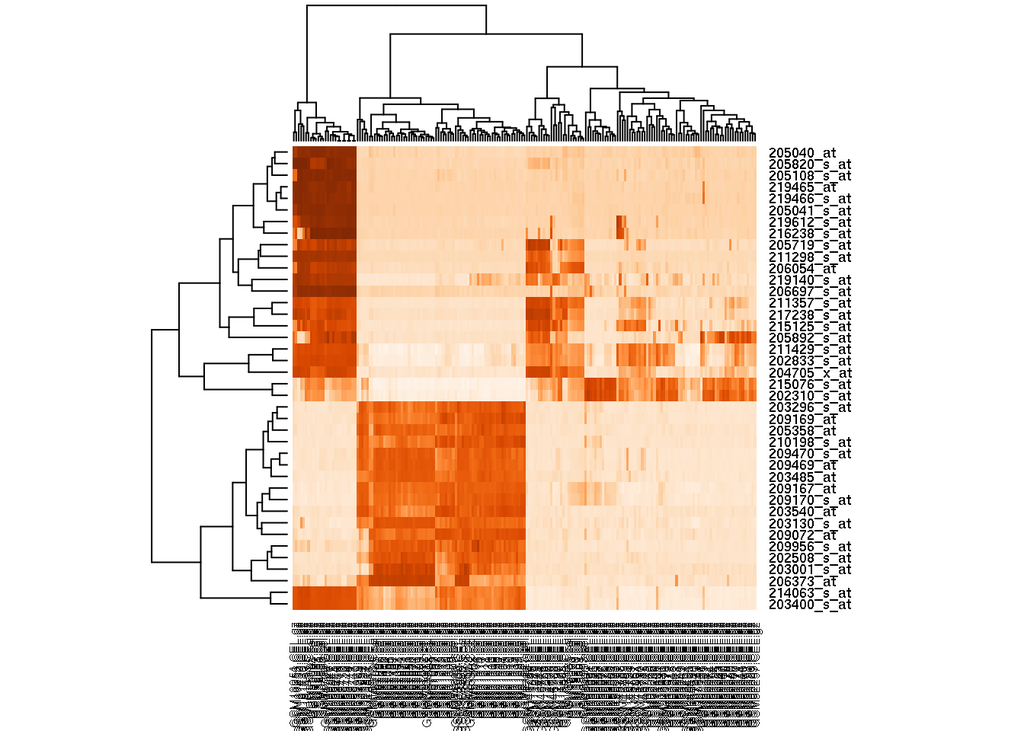

```r
#install.packages("RColorBrewer")
library(RColorBrewer)
hmcol <- colorRampPalette(brewer.pal(9, "Oranges"))(100)
rv <- rowVars(e)
idx <- order(-rv)[1:40] # to 40
heatmap(e[idx,], col=hmcol)
```

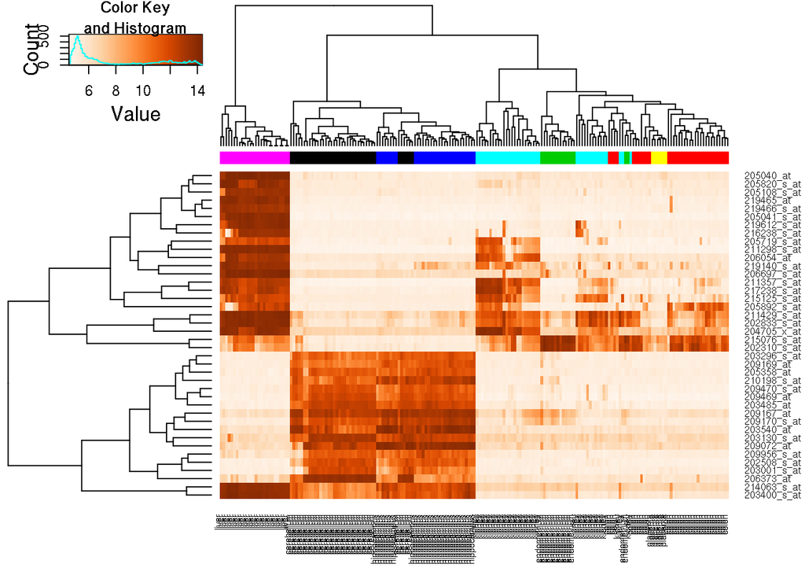

```r
#install.packages("gplots")
suppressMessages(library(gplots))
cols <- palette(brewer.pal(8, "Dark2"))[as.numeric(factor(tissue))]
heatmap.2(e[idx,], labCol=tissue,
          trace="none",
          ColSideColors=cols,
          col=hmcol)
```

## Prediction (KNN)

```r
table(tissue)
```

```
## tissue
##  cerebellum       colon endometrium hippocampus      kidney       liver
##          38          34          15          31          39          26
##    placenta
##           6
```

```r
idx <- which(tissue != "placenta") # remove
y <- tissue[idx]
X <- t(e[, idx]) # columns are the predictors
c(dim(X), length(y))
```

```
## [1]   183 22215   183
```

```r
set.seed(1)
# cross validation, train set and test set
suppressMessages(library(caret))
foldsIdx <- createFolds(y, k = 5) # five folds
sapply(foldsIdx, function(i) table(y[i]))
```

```
##             Fold1 Fold2 Fold3 Fold4 Fold5
## cerebellum      7     8     7     8     8
## colon           6     7     7     7     7
## endometrium     3     3     3     3     3
## hippocampus     6     6     6     7     6
## kidney          8     8     8     8     7
## liver           5     6     5     5     5
```

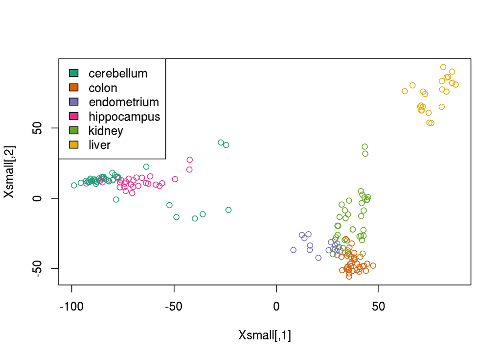

```r
Xsmall <- cmdscale(dist(X)) # apply separately for real to test set
plot(Xsmall, col=as.numeric(factor(y)))
legend("topleft",levels(factor(y)),fill=seq_along(levels(factor(y))))
```

```r
library(class)
idx <- foldsIdx
i = 1 # test fold
pred <- knn(train = Xsmall[-idx[[i]], ],
            test = Xsmall[idx[[i]], ],
            cl = y[-idx[[i]]], k = 5)
table(known=y[idx[[i]]], pred)
```

```
##              pred
## known         cerebellum colon endometrium hippocampus kidney liver
##   cerebellum           5     0           0           2      0     0
##   colon                0     6           0           0      0     0
##   endometrium          0     0           3           0      0     0
##   hippocampus          2     0           0           4      0     0
##   kidney               0     0           2           0      6     0
##   liver                0     0           0           0      0     5
```

```r
mean(y[idx[[i]]] != pred) # misclassification rate
```

```
## [1] 0.1714286
```

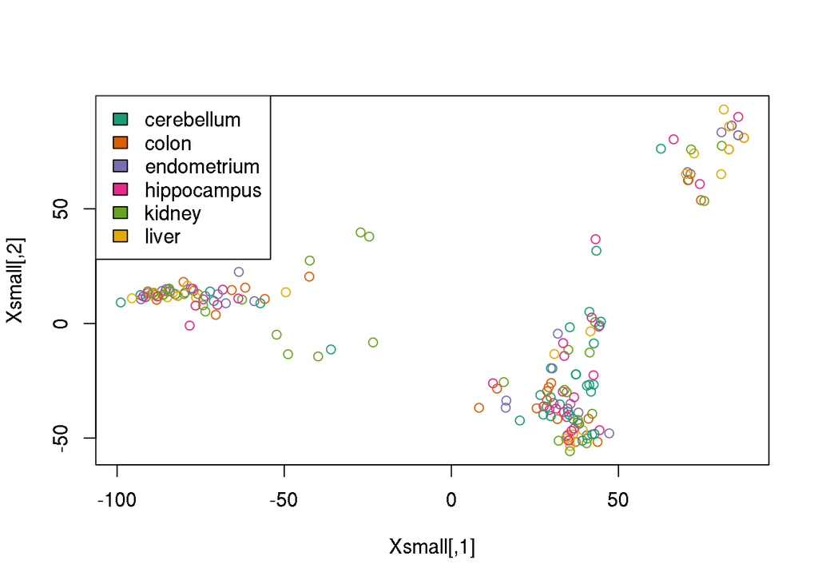

```r
plot(Xsmall, col=as.numeric(factor(pred)))
legend("topleft",levels(factor(pred)),fill=seq_along(levels(factor(pred))))
```

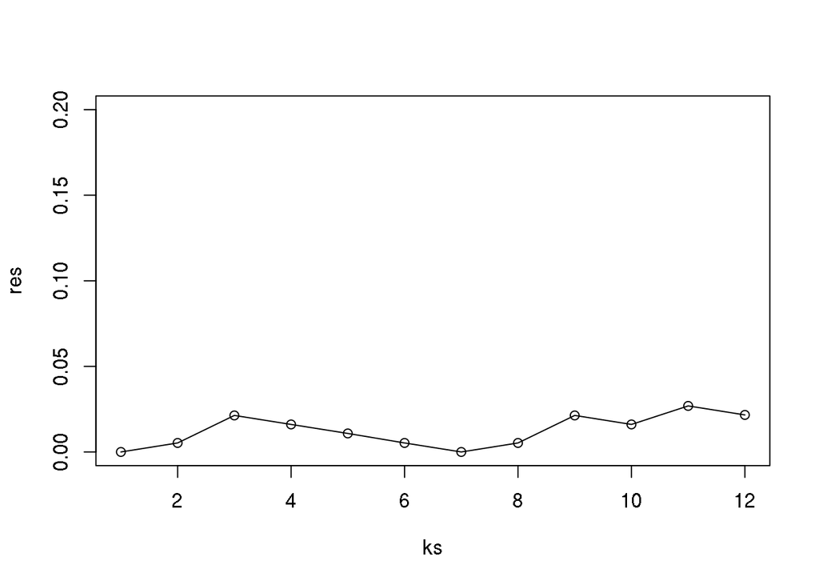

```r
Xsmall <- cmdscale(dist(X), k=5)
set.seed(1)
ks <- 1:12
res <- sapply(ks, function(k) {
  res.k <- sapply(seq_along(idx), function(i) {
  pred <- knn(train = Xsmall[ -idx[[i]], ],
                test = Xsmall[ idx[[i]], ],
                cl = y[ -idx[[i]] ], k = k)
  mean(y[ idx[[i]] ] != pred)
  })
  mean(res.k)
})
plot(ks, res, type="o", ylim=c(0,0.20))
```

## Batch Effects - ComBat

Confounding of *autosomal* chromosomes because of month in example data (histogram is not flat) (we expect only sex differences *allosome*):

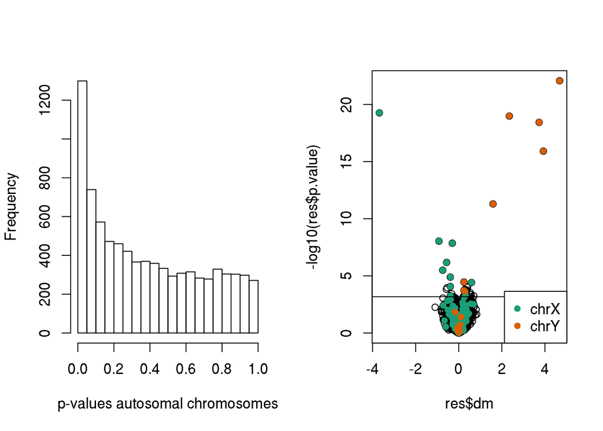

```r
chr <- geneAnnotation$CHR
res <- rowttests(geneExpression,as.factor(sampleInfo$group))
qvals <- qvalue(res$p.value)$qvalue
index <- which(qvals<0.1)

op <- par(mfrow = c(1, 2))
hist(res$p.value[which(!chr%in%c("chrX","chrY") )],main="",ylim=c(0,1300), xlab="p-values autosomal chromosomes")
plot(res$dm,-log10(res$p.value))
points(res$dm[which(chr=="chrX")],-log10(res$p.value[which(chr=="chrX")]),col=1,pch=16)
points(res$dm[which(chr=="chrY")],-log10(res$p.value[which(chr=="chrY")]),col=2,pch=16,xlab="Effect size",ylab="-log10(p-value)")
abline(h=-log10(max(res$p.value[index])))
legend("bottomright", c("chrX","chrY"), col=1:2, pch=16)
```

```r
par(op)
```

We have autosomal (non-sex-related) chromosomes over-represented:

```r
cat("Total genes with q-value < 0.1:", length(index))
```

```
## Total genes with q-value < 0.1: 41
```

```r
cat("Number of selected genes on chrY:", sum(chr[index]=="chrY", na.rm=TRUE))
```

```
## Number of selected genes on chrY: 8
```

```r
cat("Number of selected genes on chrX:", sum(chr[index]=="chrX", na.rm=TRUE))
```

```
## Number of selected genes on chrX: 11
```

```r
cat("autosomal", length(index) - sum(chr[index]=="chrY", na.rm=TRUE) - sum(chr[index]=="chrX", na.rm=TRUE))
```

```
## autosomal 22
```

We have to supply batch (month)

```r
sex <- sampleInfo$group
batch <- factor(format(sampleInfo$date,"%m"))
table( sampleInfo$group, batch)
```

```
##    batch
##     06 10
##   0  9  3
##   1  3  9
```

Linear model considering batch

```r
# full model
X <- model.matrix(~sex+batch)
j <- 7635 #sample row
y <- geneExpression[j,]
fit <- lm(y~X)
summary(fit)$coef
```

```
##                Estimate Std. Error    t value     Pr(>|t|)
## (Intercept)  7.26329968  0.1605560 45.2384140 2.036006e-22
## Xsex        -0.04023663  0.2427379 -0.1657616 8.699300e-01
## Xbatch10    -1.23089977  0.2427379 -5.0709009 5.070727e-05
```

```r
summary(fit)$coef[2,c(1,4)]
```

```
##    Estimate    Pr(>|t|)
## -0.04023663  0.86993001
```

```r
# model with batch adjust
fit <- lm(y~X - 1)
summary(fit)$coef
```

```
##                 Estimate Std. Error    t value     Pr(>|t|)
## X(Intercept)  7.26329968  0.1605560 45.2384140 2.036006e-22
## Xsex         -0.04023663  0.2427379 -0.1657616 8.699300e-01
## Xbatch10     -1.23089977  0.2427379 -5.0709009 5.070727e-05
```

```r
summary(fit)$coef[2,c(1,4)]
```

```
##    Estimate    Pr(>|t|)
## -0.04023663  0.86993001
```

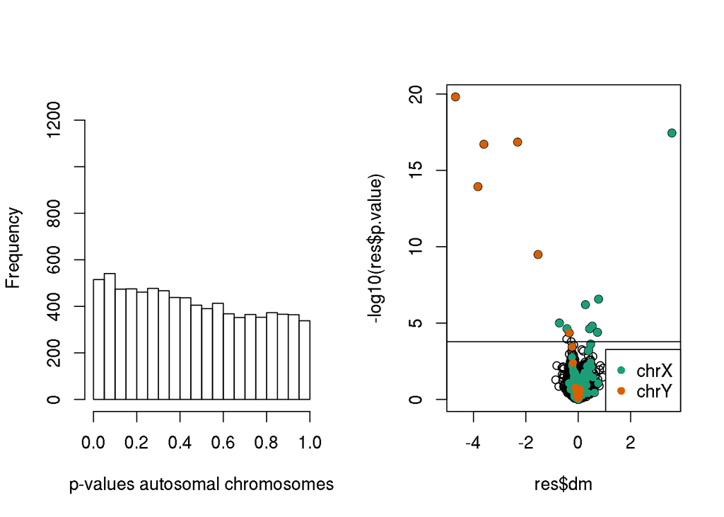

```r
# apply batch adjust model to each gene
res <- t( sapply(1:nrow(geneExpression),function(j){
  y <- geneExpression[j,]
  fit <- lm(y~X - 1)
  summary(fit)$coef[2,c(1,4)]
}))

res <- data.frame(res)
names(res) <- c("dm","p.value")
qvals <- qvalue(res$p.value)$qvalue
index <- which(qvals<0.1)

op <- par(mfrow = c(1, 2))
hist(res$p.value[which(!chr%in%c("chrX","chrY") )],main="",ylim=c(0,1300), xlab="p-values autosomal chromosomes")
plot(res$dm,-log10(res$p.value))
points(res$dm[which(chr=="chrX")],-log10(res$p.value[which(chr=="chrX")]),col=1,pch=16)
points(res$dm[which(chr=="chrY")],-log10(res$p.value[which(chr=="chrY")]),col=2,pch=16,xlab="Effect size",ylab="-log10(p-value)")
abline(h=-log10(max(res$p.value[index])))
legend("bottomright",c("chrX","chrY"),col=1:2,pch=16)
```

```r
par(op)

cat("Total genes with q-value < 0.1:", length(index))
```

```
## Total genes with q-value < 0.1: 16
```

```r
cat("Number of selected genes on chrY:", sum(chr[index]=="chrY", na.rm=TRUE))
```

```
## Number of selected genes on chrY: 6
```

```r
cat("Number of selected genes on chrX:", sum(chr[index]=="chrX", na.rm=TRUE))
```

```
## Number of selected genes on chrX: 8
```

```r
cat("autosomal", length(index) - sum(chr[index]=="chrY", na.rm=TRUE) - sum(chr[index]=="chrX", na.rm=TRUE))
```

```
## autosomal 2
```

Optimization (compute model matrix only once)

```r
suppressMessages(library(limma))
X <- model.matrix(~sex+batch - 1)
fit <- lmFit(geneExpression, X)
#fit
dim( fit$coef)
```

```
## [1] 8793    3
```

```r
k <- 2 ##second coef
ses <- fit$stdev.unscaled[,k]*fit$sigma
ttest <- fit$coef[,k]/ses
pvals <- 2*pt(-abs(ttest),fit$df)
```

## Projection and Rotation

$Ax = b$ has a solution iff $b$ is in the columnspace $C(A)$. If not, then we can project $b$ as $p$ onto $L=C(A)$ and solve $A^TA\hat{x} = A^Tb$. Then $\hat{x} = (A^T A)^{-1} A^T b$, and $p = A\hat{x}$, so the projection matrix $P = A (A^T A)^{-1} A^T$. For $P$, the following hold $P^T = P$ (symmetric) and $P^2=P$. Projection $e$ of $b$ onto orthogonal nullspace $N(A^T)$ has projection matrix $I - P$, so $e = b - p = (I - P)b$. $A^TA$ is invertible if $A^TAx = 0$ ( $A$ has only independent columns $dim(C(A)) = ncol(A)$ (where dim(C(A)) is the rank of $A$) ).

Examples:

1. Mean is a projection to $L$

$\vec{v}=\begin{pmatrix} 1\\ \vdots \\ 1\end{pmatrix}; L = \{ c \vec{v}; c \in \mathbb{R}\}$

where $\hat{c} = \bar{Y}$ is the average.

2. Linear modes are a projection to $L$:

$L = \{ \beta_0 \vec{v}_0 + \beta_1 \vec{v}_1 ; \vec{\beta}=(\beta_0,\beta_1) \in \mathbb{R}^2 \}$

with

$\vec{v}_0= \begin{pmatrix} 1\\ 1\\ \vdots \\ 1\\ \end{pmatrix} \mbox{ and } \vec{v}_1= \begin{pmatrix} X_{1}\\ X_{2}\\ \vdots \\ X_{N}\\ \end{pmatrix}$

where $\hat{c} = \hat{\beta}= (X^\top X)^{-1}X^\top \vec{y}$

**Rotation** is a projection in another subspace $L$:

$Y = AZ\\$

$A^{-1} Y = Z\\$

$Z$ and $Y$ carry the same information in different *coordinate systems*.

*Singular Value Decomposition* (SVD) is a rotation $U^\top Y$ that gives us a new coordiante system $DV^\top$ in which the dimensions are ordered by how much variance they explain.

**Principal Components**

The orthogonal vector that maximizes the sum of squares

$(\mathbf{Yv}_1)^\top \mathbf{Yv}_1$

$\mathbf{v}_1$ is referred to as the *first principal component* (PC). Also referred as *first eigenvector*, $\mathbf{Yv}_1$ are the projections or coordinates or eigenvalues

Residuals $\mathbf{r} = \mathbf{Y} - \mathbf{Yv}_1 \mathbf{v}_1^\top$

The second PC is the vector that

$\mathbf{v}_2^\top \mathbf{v}_2=1$

$\mathbf{v}_2^\top \mathbf{v}_1=0$

and maximizes $(\mathbf{rv}_2)^\top \mathbf{rv}_2$

$Y$ is $N \times m$ we repeat to find 3rd, 4th, …, m-th PCs

SVD $\mathbf{Y=UDV}^\top$ gives the PCs in columns of $\mathbf{V}$.

```r
SVD <- svd(geneExpression)
dim(SVD$v)
```

```
## [1] 24 24
```

```r
pc <- prcomp(geneExpression) # keeps only V
dim(pc$rotation)
```

```
## [1] 24 24
```

```r
for(i in 1:5) print( round( cor( pc$rotation[,i],SVD$v[,i]),3))
```

```
## [1] 0.649
## [1] 0.999
## [1] 0.93
## [1] 0.928
## [1] 0.986
```

## Batch Effects - Factor Analysis

A generalized linear model with $\alpha_{m \times k} W_{k \times n}$ for modeling batch effects

$Y_{m \times n} = \beta_{m \times p} X_{p \times n} + \alpha_{m \times k} W_{k \times n} + \epsilon_{m \times n}$

Principal components estimate $W$. $k$ is found using EDA techniques (variance exaplained by SVD$d), assuming $\beta$ is zero:

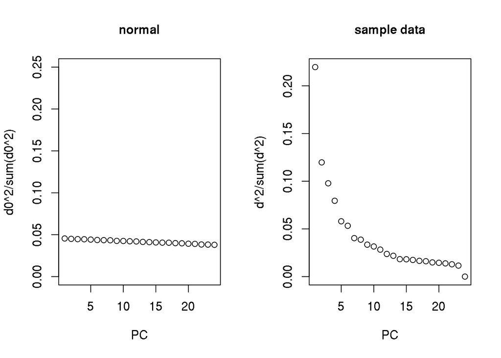

```r
library(GSE5859Subset)
data(GSE5859Subset)
sex <- sampleInfo$group
batch <- factor(format(sampleInfo$date,"%m"))
chr <- geneAnnotation$CHR
y <- geneExpression - rowMeans(geneExpression) #demean for mds plot

# data svd
SVD <- svd(y)
d <- SVD$d

# normal for comparison
y0 <- matrix( rnorm( nrow(y)*ncol(y) ) , nrow(y), ncol(y) )
d0 <- svd(y0)$d

# sample data first 2 PCs have more variability than we expect for normal independend data
op <- par(mfrow = c(1, 2))
plot(d0^2/sum(d0^2),ylim=c(0,.25), main="normal", xlab="PC")
plot(d^2/sum(d^2), main="sample data", xlab="PC")
```

```r
par(op)
```

MDS of PCs, check sex

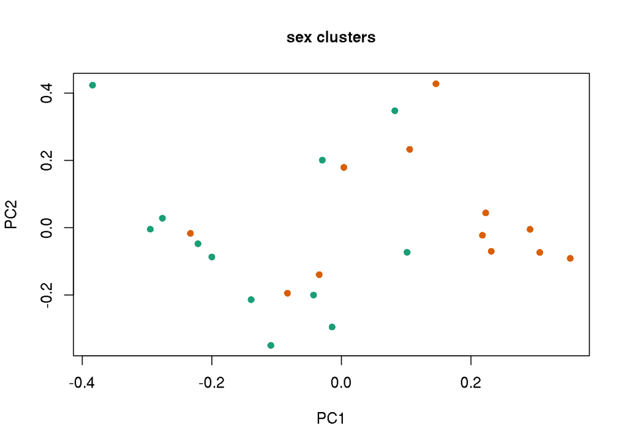

```r
#sex
cols = as.numeric(sex) + 1
plot(SVD$v[,1], SVD$v[,2], col=cols, pch=16, xlab="PC1",ylab="PC2", main="sex clusters")
```

Check date

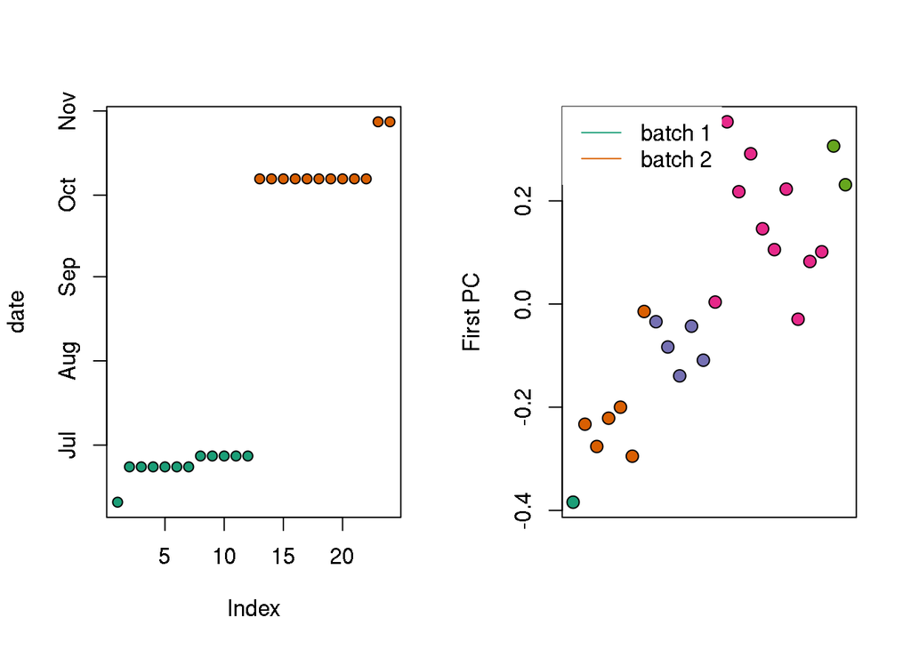

```r
times <-sampleInfo$date
o<-order(times)
op <- par(mfrow = c(1, 2))
plot(times[o],pch=21,bg=as.numeric(batch)[o],ylab="date")
cols <- as.numeric( factor(times))
plot(SVD$v[o,1],pch=21,cex=1.25,bg=cols[o],ylab="First PC",xaxt="n",xlab="")
legend("topleft",c("batch 1","batch 2"),col=1:2,lty=1,box.lwd=0)
```